# R Notebook

```r
library(tidyverse)
library(broom)
library(MASS)
library(ggplot2)
```

## Question A

The data frame is loaded using read CSV and we obtain a table that displays height and foot observations

```r
my_url <- "http://ritsokiguess.site/STAC32/heightfoot.csv"
heightfoot <- read_csv(my_url)
heightfoot
```

| height | foot |
| --- | --- |
| 66.5 | 27.0 |
| 73.5 | 29.0 |
| 70.0 | 25.5 |
| 71.0 | 27.9 |
| 73.0 | 27.0 |
| 71.0 | 26.0 |
| 71.0 | 29.0 |
| 69.5 | 27.0 |
| 73.0 | 29.0 |
| 71.0 | 27.0 |

[output cut: 23 more lines]

## Question B

There are two quantitative variables therefore we will use a scatterplot

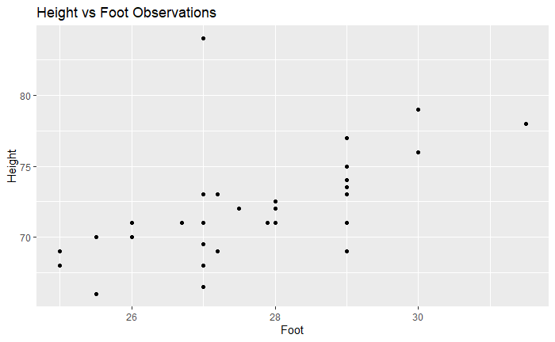

```r
ggplot(heightfoot,aes(x= foot, y = height)) +
  geom_point() + labs(title = "Height vs Foot Observations", x = "Foot", y = "Height")
```

## Question C

Our scatterplot shows a weak upward trend with an outlier around the 27 foot and 84 height data point.

## Question D

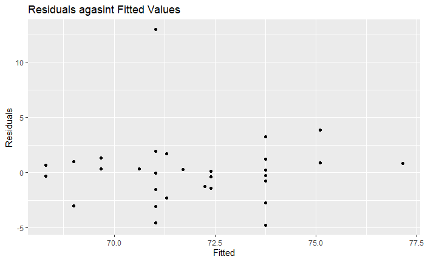

```r
hf.1 <- lm(height ~ foot, data = heightfoot)
ggplot(hf.1, aes(y=.resid, x= .fitted)) + geom_point() + labs(title = "Residuals agasint Fitted Values" , x= "Fitted", y = "Residuals")
```

A fitted regression plot of residuals against fitted values and we will use this to make a normal quantile plot of the residuals

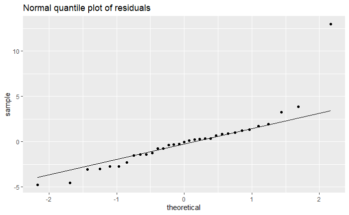

```r
ggplot(hf.1, aes(sample= .resid)) +
  stat_qq() + stat_qq_line() +  labs(title = "Normal quantile plot of residuals")
```

Normal quantile plot of the residuals where you can witness a very high outlier on the right

## Question E

As stated previously the 27 foot and 84 height data point is an outlier and in the normal quantile plot of the residuals there is a very high outlier on the right which is the same outlier. The outliers on the left and the two points before the very high outlier can be considered mild outliers that don’t deviate too much.

## Question F

Data points that we were concerned with earlier that were errors can be filtered out which creates a new data frame with less errors than before. THis removes observations that may have had errors which can change the regression line.

```r
hf.2 = heightfoot %>% filter(height<80) %>% filter (height >60)
hf.2
```

| height | foot |
| --- | --- |
| 66.5 | 27.0 |
| 73.5 | 29.0 |
| 70.0 | 25.5 |
| 71.0 | 27.9 |
| 73.0 | 27.0 |
| 71.0 | 26.0 |
| 71.0 | 29.0 |
| 69.5 | 27.0 |
| 73.0 | 29.0 |
| 71.0 | 27.0 |

[output cut: 22 more lines]

## Question G

Here we run the same plot of residuals against fitted values and a normal quantile plot except without errors.

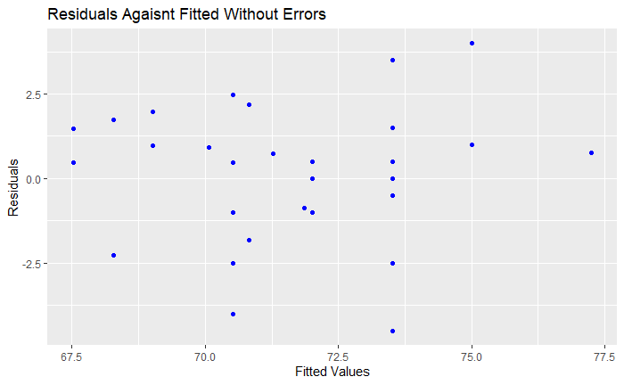

```r
hf.3 <- lm(height ~ foot, data = hf.2)
ggplot(hf.3, aes(y=.resid, x= .fitted)) + geom_point(color = "blue") + labs(title = "Residuals Agaisnt Fitted Without Errors", x = "Fitted Values", y = "Residuals")
```

- Residuals against fitted values

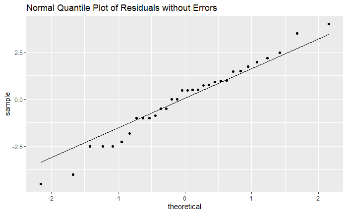

```r
ggplot(hf.3, aes(sample= .resid)) +
  stat_qq() + stat_qq_line() + labs(title = "Normal Quantile Plot of Residuals without Errors")
```

- Normal Quantile Plot of the residuals

## Question H

In the previous plot there are mild outliers that are negligible around -2.5 and 2  
Additionally Central Limit Theorem holds here since the sample size is greater than 30.

## Question I

The blue regression line is the original data with errors with the fill being in red color The purple regression line is the data filtered without errors with the fill being in green color

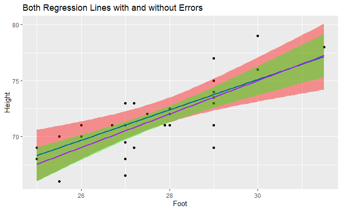

```r
ggplot(hf.2, aes(x = foot, y = height)) +
  geom_point(data = hf.2, aes(x = foot, y = height)) +
  geom_smooth(data = hf.1, method = "lm", se = TRUE, colour = "blue", fill = "red") +
  geom_smooth(data = hf.2, method = "lm", se = TRUE, colour = "purple", fill="green") +
   labs(title = "Both Regression Lines with and without Errors", x = "Foot", y = "Height")
```

##Question J Removing the observations that were errors has changed the spread of the fill to be decreased as we can see from the red fill of the blue regression line to the green fill of the purple regression line. This is expected as the outlier was causing the data to be pulled.